# 17SemanaProgramacion_230421

Algo ML en Python con POO

https://github.com/tirthajyoti/Machine-Learning-with-Python

## link para hacer el ejercicio propuesto al final

### https://github.com/tirthajyoti/Machine-Learning-with-Python/blob/master/OOP_in_ML/Class_MyLinearRegression.ipynb

Recursos Data Science

https://github.com/tirthajyoti/Data-science-best-resources

POO Python

https://github.com/arvimal/Python-and-OOP

Juego en Python con POO

https://github.com/ai006/SuperMario_Python

https://github.com/suryadutta/solitaire

https://github.com/JoannaBroniarek/TowerGame

## Abstracción

### (no confundir abstracion con clases abstractas)

El concepto de **encapsulamiento** descripto debajo se apoya sobre el concepto de abstracción.

Objects in an OOP language provide an **abstraction that hides the internal implementation details.** Similar to the coffee machine in your kitchen, you just need to know which methods of the object are available to call and which input parameters are needed to trigger a specific operation. But you don’t need to understand how this method is implemented and which kinds of actions it has to perform to create the expected result.

Data Abstraction may also **be defined as the process of identifying only the required characteristics of an object ignoring the irrelevant details.** The properties and behaviors of an object differentiate it from other objects of similar type and also help in classifying/grouping the objects.

En POO solo necesita saber como interaccionar con los objetos, no necesita conocer los detalles de cómo está implementada la clase a partir de la cual se instancia el objeto. Sólo necesita conocer su interfaz pública.

La encapsulación es una forma de abstracción, ademas es un mecanismo para llevar a la práctica la abstracción.

El nivel de abstracción puede ser bajo (en un objeto se manipulan datos y métodos individualmente), o alto (en un objeto solo se usan sus métodos de servicio).

## Clases abstractas

Un concepto importante en programación orientada a objetos es el de las clases abstractas. Unas clases en las que se pueden definir tanto métodos como propiedades, pero que **no pueden ser instancias directamente.** Solamente se pueden usar para construir subclases. Permitiendo así tener una única implementación de los métodos compartidos, evitando la duplicación de código. Veamos cómo definir las clases abstractas en Python.

## Propiedades de las clases abstractas

**La primera propiedad de las clases abstractas es que no puede ser instanciadas.** Simplemente proporciona una interfaz para las subclases derivadas y evitando así la duplicación de código.

Otra característica de estas clases es que no es necesario que tengan una implementación de todos los métodos necesarios. Pudiendo ser estos abstractos. Los métodos abstractos son aquellos que solamente tienen una declaración, pero no una implementación detallada de las funcionalidades.

Las clases derivadas de las clases abstractas debe implementar necesariamente todos los métodos abstractos para poder crear una clase que se ajuste a la interfaz definida. En el caso de que no se defina alguno de los métodos no se podrá crear la clase.

Resumiendo, las clases abstractas define una interfaz común para las subclases. Proporciona atributos y métodos comunes para todas las subclases evitando así la necesidad de duplicar código. Imponiendo además lo métodos que deber ser implementados para evitar inconsistencias entre las subclases.

## Creación de clases abstractas en Python

Para poder crear clases abstractas en Python es necesario importar la clase ABC y el decorador abstractmethod del modulo abc (Abstract Base Classes). Un módulo que se encuentra en la librería estándar del lenguaje, por lo que no es necesario instalar. Así para definir una clase privada solamente se tiene que crear una clase heredada de ABC con un método abstracto.

```python
from abc import ABC, abstractmethod
class Animal(ABC):
    @abstractmethod
    def mover(self):
        pass
```

Ahora si se intenta crear una instancia de la clase animal, Python no lo permitirá indicando que no es posible. Es importante notar que que si la clase no hereda de ABC o contiene por lo menos un método abstracto, Python permitirá instancias las clases.

```python
class Animal(ABC):
    #No contiene métodos abstractos
    def mover(self):
        pass

#Permite instacias
Animal()
```

```
<__main__.Animal at 0x2002ed596c8>
```

```python
#No hereda de ABC
class Animal():
    @abstractmethod
    def mover(self):
        pass

    #Permite instacias
Animal()
```

```
<__main__.Animal at 0x2002ed56448>
```

## Métodos en las subclases

Las subclases tienen que implementar todos los métodos abstractos, en el caso de que falta alguno de ellos Python no permitirá instancias tampoco la clase hija.

```python
class Animal(ABC):
    @abstractmethod
    def mover(self):
        pass

    @abstractmethod
    def comer(self):
        print('Animal come')

class Gato(Animal):
    def mover(self):
        print('Mover gato')

g = Gato() # Error
```

```
---------------------------------------------------------------------------
TypeError                                 Traceback (most recent call last)
<ipython-input-10-069aed237df2> in <module>
     12         print('Mover gato')
     13
---> 14 g = Gato() # Error

TypeError: Can't instantiate abstract class Gato with abstract methods comer
```

Por otro lado, desde los métodos de las subclases podemos llamar a las implementaciones de la clase abstracta con el comando super() seguido del nombre del método.

```python
class Animal(ABC):
    @abstractmethod
    def mover(self):
        pass

    @abstractmethod
    def comer(self):
        print('Animal come')

class Gato(Animal):
    def mover(self):
        print('Mover gato')

    def comer(self):
        #Observar que imprime "Animal come"
        # al llamar al método abstracto "comer"
        super().comer()
        print('Gato come')

g = Gato()
g.mover()
g.comer()
```

```
Mover gato
Animal come
Gato come
```

## Encapsulamiento

El encapsulamiento se considera una de las características definitorias de la POO.

Cuando una clase existe (se define), se crean objetos a partir de ella, y se usan dichos objetos llamando los métodos necesarios. Es decir, crea objetos para usar los servicios que nos proporciona la clase a través de sus métodos.

No necesita saber cómo trabaja el objeto, ni saber las variables que usa, ni el código que contiene.

El objeto es una caja negra. Es decir, el objeto es un proveedor que proporciona servicios a los clientes que lo solicitan.

La encapsulación describe el hecho de que los objetos se usan como cajas negras. Así, un objeto encapsula datos y métodos, que están dentro del objeto.

**Interfaz pública de una clase:** Es el conjunto de métodos (métodos de servicio) que sirve para que los objetos de una clase proporcionen sus servicios. Estos servicios son los que pueden ser llamados por un cliente.

**Métodos de soporte:** Son métodos adicionales en un objeto que no definen un servicio utilizable por un cliente, pero que ayudan a otros métodos en sus tareas.

La encapsulación es un mecanismo de control. El estado (el conjunto de propiedades, atributos ó datos) de un objeto sólo debe ser modificado por medio de los métodos del propio objeto.

La técnica de encapsulación, es conocida como **ocultación de datos**, le permite que los atributos de un objeto pueden ocultarse (superficialmente) para que no sean accedidos desde fuera de la definición de una clase. Para ello, es necesario nombrar los atributos con un prefijo de doble subrayado: __atributo.

```python
#Crea clase "Factura"
class Factura:
    #Atributo de tipo privado, está oculto, encapsulado
    __tasa = 19 #Atributo privado
    def __init__(self, unidad, precio):
        self.unidad = unidad
        self.precio = precio
    def por_pagar(self):
        total = self.unidad * self.precio
        #Observar que __tasa se puede usar dentro de la clase propietaria.
        impuesto = total * Factura.__tasa / 100
        return(total + impuesto)

#Instancia objeto "compra1" de tipo "Factura"
compra1 = Factura(12, 110)
#Llamada a atributo "unidad"
print(compra1.unidad)
```

```
12
```

```python
#Llamada a atributo "precio"
print(compra1.precio)
```

```
110
```

```python
#Llamada a método "por_pagar()"
print(compra1.por_pagar(), "bitcoins")
```

```
1570.8 bitcoins
```

```python
#Error al llamar al atributo privado "__tasa"
print(Factura.__tasa)
```

```
---------------------------------------------------------------------------
AttributeError                            Traceback (most recent call last)
<ipython-input-5-b059e6a00ec7> in <module>
----> 1 print(Factura.__tasa)

AttributeError: type object 'Factura' has no attribute '__tasa'
```

## Polimorfismo

La técnica de polimorfismo de la POO significa la capacidad de tomar más de una forma. Una operación puede presentar diferentes comportamientos en diferentes instancias. El comportamiento depende de los tipos de datos utilizados en la operación. El polimorfismo es ampliamente utilizado en la aplicación de la herencia.

```python
class Persona():
    def __init__(self):
        self.cedula = 13765890
    def mensaje(self):
        print("mensaje desde la clase Persona")

class Obrero(Persona):
    def __init__(self):
        self.__especialista = 1

    def mensaje(self):
        print("mensaje desde la clase Obrero")

    #def mensaje(self, mensaje):
    #    print(mensaje)

obrero_planta = Obrero()
obrero_planta.mensaje()
#obrero_planta.mensaje("Pepe")
```

```
mensaje desde la clase Obrero
```

Lo que se logra definiendo el método mensaje() en la Clase Derivada (Obrero) se conoce como Método Overriding (cuando se cree el objeto (en este caso obrero_planta y se llame al método mensaje(), este será tomado de la propia clase y no de la Clase Base Persona). Si comenta o borra el método mensaje() de la clase Obrero (Clase Derivada) y corre nuevamente el código, el método llamado será el mensaje() de la Clase Base Persona.

```python
class Persona():
    def __init__(self):
        self.cedula = 13765890
    def mensaje(self):
        print("mensaje desde la clase Persona")

class Obrero(Persona):
    def __init__(self):
        self.__especialista = 1

    def mensaje(self):
        print("mensaje desde la clase Obrero")

    def mensaje(self, mensaje):
        print(mensaje)

obrero_planta = Obrero()
#obrero_planta.mensaje()
obrero_planta.mensaje("Pepe")
```

```
Pepe
```

```python
obrero_planta.mensaje()
```

```
---------------------------------------------------------------------------
TypeError                                 Traceback (most recent call last)
<ipython-input-8-952703bfada9> in <module>
----> 1 obrero_planta.mensaje()

TypeError: mensaje() missing 1 required positional argument: 'mensaje'
```

## Atencion

“La sobrecarga de métodos o comúnmente llamada Overloading es un práctica que consiste en tener diferentes métodos con el mismo nombre en una misma clase, y que el intérprete o compilador logre diferenciarlos por los tipos de datos que se envían como argumentos para los parámetros.”

**En Python la sobrecarga de métodos en la misma clase (overloading) como tal, NO EXISTE.** Quienes vienen de otros lenguajes como Java o C# se encuentran con algunas confusiones puesto que es algo muy común en ese lenguaje… En python, la sobrecarga resulta absurda, aunque hay quienes han redactado sobre ello asegurando que es “una buena práctica en cualquier lenguaje”.

## Sobrecarga de Operadores

La sobrecarga de operadores es también es conocida por **Overloading Operators**, trata básicamente de lo mismo que la sobrecarga de métodos pero pertenece en esencia al ámbito de los operadores aritméticos, binarios, de comparación y lógicos.

## Tabla de operadores:

En la arquitectura de Python cada objeto tiene varios métodos especializados que se usan para interactuar con otros objetos o con operadores nativos de Python, regularmente estos métodos siguen una nomenclatura predefinida en el modelo de datos de Python, esta nomenclatura es la siguiente:

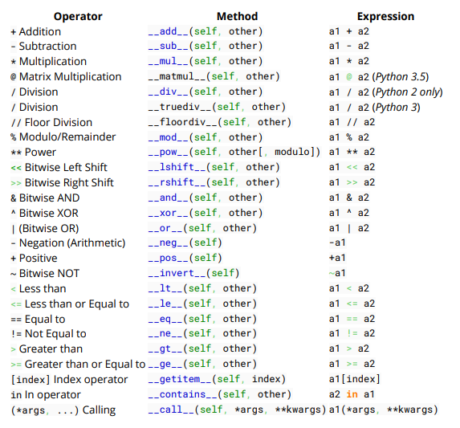

Dado que en Python hay varias funciones nativas también se pueden sobrecargar y operar con instancias de objetos, a continuación, se muestra una tabla con las funciones que se pueden sobrecargar.

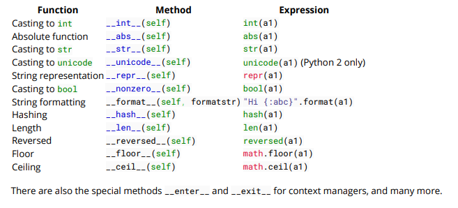

```python
class Vector(object):

    def __init__ (self, x, y):
        self.x = x
        self.y = y

    def __add__ (self, v):
        # Sumar dos Vectores
        return Vector (self.x + v.x, self.y + v.y)

    def __sub__ (self, v):
        # Restar dos Vectores
        return Vector (self.x - v.x, self.y - v.y)

    def __mul__ (self, s):
        # Multiplicar un Vectores por un escalar
        return Vector (self.x * s, self.y * s)

    def __repr__ (self):
        # <__main__.Vector instance at 0x01DDDDC8>.
        return '<Vector (%f, %f)>' % (self.x, self.y)
```

```python
#Suma vectorial sobrecargada
a = Vector (3, 5)
b = Vector (2, 7)
print(a + b) # Output: <Vector (5.000000, 12.000000)>
```

```
<Vector (5.000000, 12.000000)>
```

```python
#Resta vectorial sobrecargada
a = Vector (3, 5)
b = Vector (2, 7)
c = b - a
print(c) # Output: <Vector (-1.000000, 2.000000)>
```

```
<Vector (-1.000000, 2.000000)>
```

```python
#Producto vectorial sobrecargada
a = Vector (3, 5)
b = Vector (2, 7)
print(b * 1.3) # Output: <Vector (2.600000, 9.100000)>
```

```
<Vector (2.600000, 9.100000)>
```

## Sin usar sobrecarga - Comparar código.

El código quedaría así.

```python
class Vector(object):
    def __init__ (self, x, y):
        self.x = x
        self.y = y

    def __repr__ (self):
        # <__main__.Vector instance at 0x01DDDDC8>.
        return '<Vector (%f, %f)>' % (self.x, self.y)
```

```python
a = Vector (3, 5)
b = Vector (2, 7)
```

```python
#Suma sin sobrecarga
x1 = a.x + b.x
y1 = a.y + b.y
result = Vector (x1, y1)
print(result)
```

```
<Vector (5.000000, 12.000000)>
```

```python
#Resta sin sobrecarga
x1 = a.x - b.x
y1 = a.y - b.y
result = Vector (x1, y1)
print(result)
```

```
<Vector (1.000000, -2.000000)>
```

## Ejercicio:

Descargar el jupyter y analizar hasta el final.

1- Detectar conceptos: abstracción, encapsulamiento, sobrecarga, polimorfismos, métodos, atributos, herencia (multiple???).

2- ¿Que acciones haría para realizar una clase para regresión logística?

3- ¿Que reutilizaría?

4- ¿Y si fueran polinómicas las regresiones?

5- ¿Y si quisiera comparar la perfomance de distintos métodos de ajuste/ entrenamiento?